# SS3 to opal: North Pacific blue shark

Bridging the 2022 ISC two-sex assessment to a single-sex Stock Synthesis model, and from it to opal

Author

Nicholas Ducharme-Barth

Published

October 30, 2026

**Setup: read the caches**

```r
# Code is shown (folded) in the HTML version and hidden in the PDF.
knitr::opts_chunk$set(echo = knitr::is_html_output())
library(data.table)
library(ggplot2)
library(patchwork)

bridge  = readRDS(file.path("data", "npo-bsh-ss3-bridge-cache.rds"))
profile = readRDS(file.path("data", "npo-bsh-ss3-r0-profile-cache.rds"))
opal_c  = readRDS(file.path("data", "npo-bsh-opal-cache.rds"))

theme_set(theme_bw(base_size = 11) +
          theme(legend.position = "bottom", panel.grid.minor = element_blank()))
fmt = function(x, d = 2) formatC(x, format = "f", digits = d, big.mark = ",")
sci = function(x, d = 1) formatC(x, format = "e", digits = d)

B = bridge$summary
P = profile$profile
S = opal_c$summary
step_lab = setNames(bridge$labels, bridge$steps)
model_col = c("SS3 B2e" = "grey20", O0 = "#7D3C98", O1 = "#2471A3", O2 = "#C0392B",
              `O1-noLF` = "#CA6F1E", `O1-mid` = "#1E8449")
```

# 1 Overview

The 2022 ISC stock assessment of North Pacific blue shark (*Prionace glauca*) (ISC Shark Working Group 2022) uses Stock Synthesis (SS3 3.30.19) with two sexes. Stock status comes from an ensemble of three models that differ only in the late-period abundance index and the weighting of one fleet’s length data. This case study uses the most heavily weighted of them, S6_base (S6 here). S6 models sex-specific growth, natural mortality and selectivity, and fits joint sex-by-length compositions. opal tracks one population vector, so S6 cannot be converted directly.

This case study therefore bridges in two stages:

1. **Within SS3** (Section 3), from S6 to a single-sex SS3 model (B2e) whose structure opal can represent, one change at a time, so the effect of each change is measured on its own.
2. **SS3 to opal** (Section 4), converting B2e with the shared converter in `shared/ss3-to-opal/`, checking the conversion, then fitting opal (Section 5).

Section 6 lists where opal falls short of SS3 or differs from it, and what opal would need to model S6 itself.

```r
s6  = B[step == "00-s6-base"]
b1  = B[step == "01-single-sex"]
b2e = B[step == "02e-no-f-ballpark"]
```

# 2 The 2022 assessment

This section summarises the assessment report (ISC Shark Working Group 2022); section numbers (§) and “report” tables and figures refer to it.

## 2.1 Stock, fisheries and data

The ISC Shark Working Group (SHARKWG) assesses two Pacific stocks, north and south of the equator. Blue shark are scarce in the tropics, and no tagged shark has been recorded crossing the equator, although there is no genetic evidence of separate hemispheric populations (§2.1.1). Within the North Pacific the stock mixes widely but is segregated by size and sex. Pupping grounds lie at about 35-40°N in the northwest and 25-50°N in the northeast. Subadult females are found further north (35-50°N) than subadult males (30-40°N) (§2). The model has one area: the North Pacific north of the equator, annually from 1971 to 2020 (§3.1-3.2).

The catch is total dead removals (landings plus dead discards) (§3.4):

- Japan, Chinese-Taipei, Mexico and the USA take more than 90% of it.
- It peaked at about 70,900 t in 1981.
- It averaged 29,600 t a year over 2011-2020.
- Since the high-seas driftnet ban in 1993, 89-97% of it has come from longlines.

Most of the catch is taken by three fleets: Japanese offshore shallow-set longline (F4), Japanese distant-water deep-set longline (F7) and Taiwanese small-scale longline (F20). In the 1980s and early 1990s the high-seas driftnet fleets (F8 large mesh, F11 small mesh) also caught large amounts. Two pairs of fleets are new since the 2017 assessment: Japan’s large-mesh driftnet was split at the 1993 move from the high seas into the EEZ (F8 and F9), and the Hawaii longline into deep-set and shallow-set fleets (F17 and F18). F11, F17 and F18 report catch in numbers and all other fleets in weight (report Table 1).

The 11 candidate abundance indices are listed in report Table 3. Every model in the ensemble fits the Japanese Kinkai shallow-set longline index for the early period (S5, 1976-1993). The models differ in the late-period index (1994-2020):

- **S6:** the same fleet’s late-period index, which is what S6_base fits.
- **S11:** a dynamic-factor-analysis composite of the Hawaii deep-set (S1), Taiwanese large-scale (S3) and Japanese research and training vessel (S7) indices.

The other indices have lambda 0 and were used only in sensitivity runs. Sex-specific length compositions (precaudal length, PCL, in 5 cm bins) come from 14 fisheries. F11’s single 1991 sample is sex-combined, on different bins, and enters as generalised size-frequency data (report Table 5, §4.4.3).

Data weighting was done in two steps (§4.2.3):

- **Indices.** Where an index’s mean CV was below the RMSE of a loess fit, its CV was raised by an additive variance adjustment (report Table 6). S5, S6 and S11 were not adjusted.
- **Length compositions.** Every fleet’s variance adjustment is 0.002161 = 50/23,142. This scales the input sample sizes so that the fleet with the most fish measured (F4) averages about 50. Francis’s TA1.8 then down-weighted F4 further. The files match: 0.002161 for every length-composition fleet and 0.000652 for F4.

## 2.2 Biology

The biological parameters are fixed (report Table 8, §4.3):

- **Growth.** Sex-specific von Bertalanffy growth (SS3’s Richards curve with shape 1), from vertebrae of 620 females and 659 males measuring 33-258 cm PCL (Fujinami et al. 2019, cited in the report). Females reach L<sub>1</sub> = 64.3 cm at age 1 and L<sub>2</sub> = 245.2 cm at age 20, with K = 0.146; males 68.2 cm, 261.5 cm and 0.117. CV of length-at-age 0.25 at age 1 and 0.1 at age 20. Pups are born at about 36 cm PCL (§2.1.3).
- **Natural mortality.** Age- and sex-specific, inversely proportional to length, scaled to a meta-analytic constant. For females it falls from 0.79 at age 0 to 0.15 at age 24 (report Table 9).
- **Maturity.** Female maturity is length-logistic with 50% at 156.6 cm PCL, about age 5-6; males mature at about 161 cm and age 6 (§2.1.3). Litters of 15-112 pups (mean 35.5) have been observed in the northwestern Pacific, and females reproduce annually after 11-12 months’ gestation (§2.1.2).
- **Spawner-recruit relationship.** Beverton-Holt with h = 0.613, from a life-history simulation (Kai and Fujinami 2018, cited in the report), and sigma<sub>R</sub> = 0.4, tuned. It replaces the low-fecundity relationship used in 2017, whose parameters rested on strong assumptions (§4.3.3).
- **Initial state.** The stock is not assumed unfished in 1971: the population starts in equilibrium with 40,000 t a year of F4 catch, about the average of the first four years’ catch (§4.3.4, §4.4.2). SSB<sub>1971</sub> is about 70% of unfished (§8.1).

## 2.3 The ensemble and S6_base

The SHARKWG could not single out a best model on the diagnostics, so stock status comes from a hypothesis tree with three branches (§5.2):

- **S6_base** (weight 50%) fits S6 for the late period.
- **S11_base** (25%) fits S11 instead.
- **S11_ess** (25%) is S11_base with F20’s anomalously large 2018 and 2020 length samples (20,416 and 21,571 fish) down-weighted to 1,513. This removes a retrospective pattern in S11_base.

Each model’s uncertainty was represented by a multivariate-lognormal bootstrap, and the three bootstraps were combined according to these weights. On the combined distribution (report Table 18):

- SSB<sub>2020</sub>/SSB<sub>MSY</sub> is 1.17 (80% interval 0.57-1.78);
- F<sub>2017-2019</sub>/F<sub>MSY</sub> is 0.45 (0.24-1.01);
- the probability that the stock is neither overfished nor subject to overfishing is 61.9%.

The report notes that natural mortality and steepness, the most uncertain assumptions, are outside the ensemble.

The report’s diagnostics for S6_base (§6.1.1) bear on what follows:

- It converged (maximum gradient 9.7 x 10<sup>-5</sup>) with a positive-definite Hessian.
- The ln(R<sub>0</sub>) profile is driven by the recruitment penalty. The index and length data both favour a slightly lower R<sub>0</sub>, and within the indices the early (S5) and late (S6) series conflict (report Figures 11-12).
- There is a three-year retrospective pattern (Mohn’s rho -0.2 for SSB and 0.27 for F/F<sub>MSY</sub>).
- Female selectivity is estimated to be much lower than male selectivity in nearly every fishery. Only F18 approaches full selection of females, and F11 is sex-invariant (report Figure 26, §8.4).
- Recruitment shows a large pulse in 1986-1988 and has been below the stock-recruit curve for the last two decades.

```r
knitr::kable(data.table(
    Feature = c("Time", "Sexes and ages", "Fleets", "Catch", "Biology",
                "Spawner-recruit", "Fishing mortality", "Selectivity",
                "Indices", "Compositions", "Other likelihood terms"),
    `S6 setting` = c(
        "1971-2020, annual, one season (two subseasons), spawning in month 1",
        "Two sexes, ages 0-24",
        "20 fisheries and 11 surveys",
        "Weight (mt) except fleets 11, 17 and 18 (1000s of fish)",
        "Sex-specific age-specific M (fixed); Richards growth with shape 1 (von Bertalanffy) by sex, fixed; length-logistic maturity; 45 pups per mature female",
        "Beverton-Holt, h = 0.613 and sigma_R = 0.4 fixed; main deviations 1971-2020, early deviations 1961-1970; regime offset on the initial equilibrium; initial F on F4, fitted to a 40,000 t initial-equilibrium catch",
        "Hybrid (method 3)",
        "Size-based double normal (pattern 24) with female offsets from the male curve; F18 cubic spline with a male dogleg; six fisheries and all surveys mirror another fleet; F8 time blocks (1973-81, 1982-92); annual deviations on F19's peak",
        "Floating q; extra SD added to the CV; only S5 and S6 (Japanese longline early and late) have lambda 1",
        "Joint sex x length (5 cm bins, 5-300 cm), multinomial with a variance adjustment of 0.002161 (F4 0.000652); one size-frequency observation (F11, 1991)",
        "F-ballpark penalty (F = 0.2 in 2013); initial-equilibrium regime")),
    format = "pipe")
```

Table 1: Structure of S6, from the model files.

| Feature | S6 setting |
| --- | --- |
| Time | 1971-2020, annual, one season (two subseasons), spawning in month 1 |
| Sexes and ages | Two sexes, ages 0-24 |
| Fleets | 20 fisheries and 11 surveys |
| Catch | Weight (mt) except fleets 11, 17 and 18 (1000s of fish) |
| Biology | Sex-specific age-specific M (fixed); Richards growth with shape 1 (von Bertalanffy) by sex, fixed; length-logistic maturity; 45 pups per mature female |
| Spawner-recruit | Beverton-Holt, h = 0.613 and sigma_R = 0.4 fixed; main deviations 1971-2020, early deviations 1961-1970; regime offset on the initial equilibrium; initial F on F4, fitted to a 40,000 t initial-equilib… |
| Fishing mortality | Hybrid (method 3) |
| Selectivity | Size-based double normal (pattern 24) with female offsets from the male curve; F18 cubic spline with a male dogleg; six fisheries and all surveys mirror another fleet; F8 time blocks (1973-81, 1982-92… |
| Indices | Floating q; extra SD added to the CV; only S5 and S6 (Japanese longline early and late) have lambda 1 |
| Compositions | Joint sex x length (5 cm bins, 5-300 cm), multinomial with a variance adjustment of 0.002161 (F4 0.000652); one size-frequency observation (F11, 1991) |
| Other likelihood terms | F-ballpark penalty (F = 0.2 in 2013); initial-equilibrium regime |

## 2.4 The files against the report

The S6 files are the S6_base control file printed in the report’s appendix, and S6 re-runs with SS3 3.30.22.1 to the same likelihood. The files, which are what this case study converts, differ from the report’s text in a few places:

- **Recruitment timing.** §4.3.3 says recruitment occurs at the start of the year. In the files (and in the printed control file) recruits settle in month 7, while spawning is in month 1. This matters for the conversion (Section 4).
- **sigma<sub>R</sub>.** Report Table 8 gives 0.3, but §4.3.3, the files and the printed control file use the tuned 0.4.
- **Growth.** §4.3.5 quotes the 2017 values (L<sub>1</sub> 64.4 cm, L<sub>2</sub> 244.6 cm, K 0.147 for females). The files use the updated values in report Table 8 (64.3 cm, 245.2 cm, 0.146).
- **Fecundity.** Report Table 8 lists litter size proportional to length (-45.54 + 0.46 L). §4.3.7 says length-specific fecundity was not used in the final runs, and the files agree: fecundity option 2 with a = 45 and b = 0, so every mature female produces 45 pups. Spawning output is therefore a number of pups (in thousands) proportional to the number of mature females. The report labels it in tonnes; this document labels it in pups.
- **Penalties not described in the report.** The files hold an F-ballpark penalty (F = 0.2 in 2013) and an estimated regime offset on the initial equilibrium recruitment. Both are removed in the bridge (Section 3).

```r
knitr::kable(data.table(
    Quantity = c("SSB0", "SSB MSY", "F MSY", "SSB2020 / SSB MSY", "F2020 / F MSY"),
    `S6 (this re-run)` = c(fmt(s6$ssb0, 0), fmt(s6$ssb_msy, 0), fmt(s6$f_msy, 2),
                           fmt(s6$ssb_2020 / s6$ssb_msy, 2), fmt(s6$f_2020, 2)),
    `Ensemble (report)` = c("222,736", "83,545", "0.76", "1.17", "0.45 (2017-2019)")),
    format = "pipe", align = "lrr")
```

Table 2: S6 re-run with SS3 3.30.22.1 against the three-model ensemble (ISC 2022, Tables 17-18). The ensemble’s SSB0, SSB MSY and F MSY are weighted means of the three models; the 2020 ratios are bootstrap medians.

| Quantity | S6 (this re-run) | Ensemble (report) |
| --- | --- | --- |
| SSB0 | 243,875 | 222,736 |
| SSB MSY | 89,706 | 83,545 |
| F MSY | 0.73 | 0.76 |
| SSB2020 / SSB MSY | 1.53 | 1.17 |
| F2020 / F MSY | 0.34 | 0.45 (2017-2019) |

S6 alone is more optimistic than the ensemble. Its SSB<sub>2020</sub>/SSB<sub>MSY</sub> of 1.53 is above the ensemble median of 1.17, which is pulled down by the two S11 models. This case study converts S6 alone, so its comparisons say nothing about the ensemble’s stock status.

# 3 The SS3 bridge

`scripts/01-build-ss3-bridge.r` builds each step from the previous step’s estimates and re-estimates it with SS3 3.30.22.1 (with the Hessian). Each step makes one change:

- **S6**: as supplied, re-run with 3.30.22.1.
- **B1**: single sex (`Nsexes = -1`); female growth, M and weight-length; compositions summed over sex; no sex-offset selectivity.
- **B2a**: F18’s cubic spline replaced by a double normal.
- **B2b**: F8’s two selectivity blocks become F8 (1973-81) and a new fleet 32 (1982-92).
- **B2c**: no annual deviations on F19’s peak.
- **B2d**: no initial-equilibrium regime offset.
- **B2e**: no F-ballpark penalty.

```r
stopifnot(all(B$hessian_ok))
knitr::kable(B[, .(Step = label, `Est. par.` = n_par,
                   NLL = fmt(nll, 2), SSB0 = fmt(ssb0, 0),
                   `SSB2020/SSB0` = fmt(depletion, 3), `F2020/F MSY` = fmt(f_2020, 3),
                   `SSB MSY` = fmt(ssb_msy, 0))],
             format = "pipe", align = "lrrrrrr")
```

Table 3: The SS3 bridge. All steps converged (maximum gradient below 2e-4) with a positive-definite Hessian and no parameter on a bound.

| Step | Est. par. | NLL | SSB0 | SSB2020/SSB0 | F2020/F MSY | SSB MSY |
| --- | --- | --- | --- | --- | --- | --- |
| S6 | 194 | 32.30 | 243,875 | 0.564 | 0.337 | 89,706 |
| B1 single sex | 127 | 9.42 | 274,705 | 0.255 | 0.758 | 80,447 |
| B2a F18 double normal | 124 | 9.60 | 274,690 | 0.256 | 0.757 | 80,456 |
| B2b F8 split | 127 | 9.54 | 274,765 | 0.255 | 0.758 | 80,479 |
| B2c no F19 devs | 110 | 10.77 | 277,354 | 0.277 | 0.700 | 81,354 |
| B2d no regime | 109 | 10.77 | 277,490 | 0.276 | 0.701 | 81,396 |
| B2e no F ballpark | 109 | 9.16 | 349,989 | 0.536 | 0.345 | 102,018 |

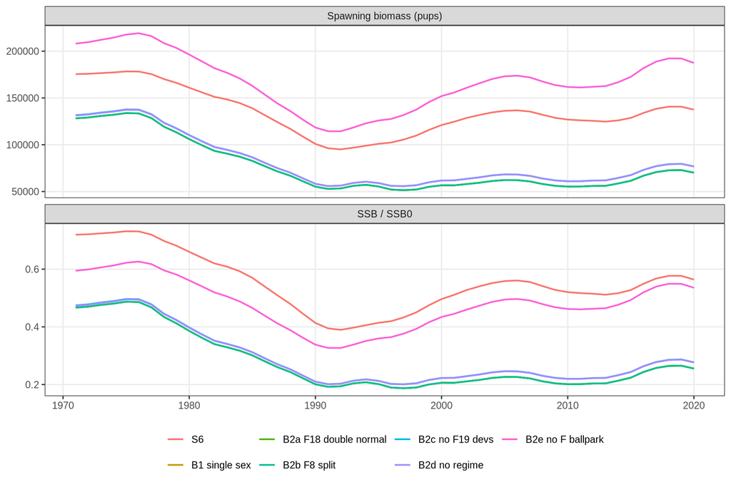

Figure 1: Spawning biomass (top) and depletion (bottom) along the SS3 bridge.

```r
ts = copy(bridge$timeseries)
ts[, label := factor(label, levels = bridge$labels)]
long = melt(ts[, .(label, year, `Spawning biomass (pups)` = ssb, `SSB / SSB0` = depletion)],
            id.vars = c("label", "year"))
ggplot(long, aes(year, value, colour = label)) +
    geom_line(linewidth = 0.7) +
    facet_wrap(~variable, ncol = 1, scales = "free_y") +
    labs(x = NULL, y = NULL, colour = NULL) +
    guides(colour = guide_legend(nrow = 2))
```

The three groups of steps tell different stories:

- **Single sex (B1)** changes the fit to the compositions most: the length NLL falls from 114.8 to 91.5, at least partly because the combined-sex compositions have half the cells of the sex-by-length ones, so the two NLLs are not directly comparable. Its scale is lower and its terminal depletion 0.255 against S6’s 0.564. The single-sex model uses female growth (245 cm at age 20) for males too (261 cm in S6), and each selectivity curve becomes S6’s male curve. In S6, females are much less selected than males of the same length in nearly every fishery (report §6.1.1). B1 therefore exposes the spawning females to the males’ selectivity, which is one plausible reason for its more depleted spawning stock.
- **Structural simplifications (B2a-B2d)** change little: the F18 spline, the F8 split and the regime offset each move the likelihood by less than 0.2 units. Removing F19’s selectivity deviations costs 1.2 units and moves depletion from 0.255 to 0.277.
- **No F-ballpark (B2e)** moves the likelihood by 1.6 units but the scale a long way: SSB<sub>0</sub> from 277,490 to 349,989 and depletion to 0.536.

## 3.1 How well is scale determined?

`scripts/02-profile-ss3-r0.r` fixes ln(R<sub>0</sub>) on a grid and re-estimates every other parameter.

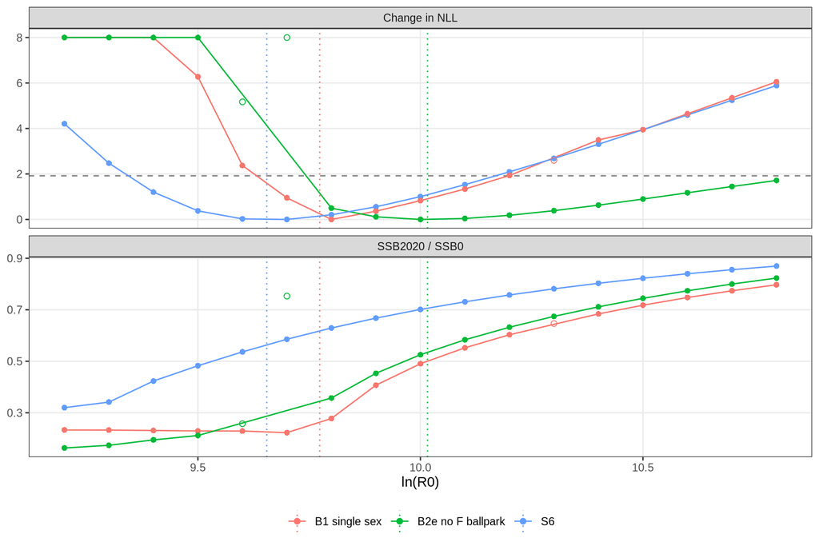

Figure 2: Likelihood profiles over ln(R0) for S6, B1 and B2e (top: change in total NLL, capped at 8, with the 1.92 line of an approximate 95% interval; bottom: terminal depletion). Open points did not converge. The vertical lines are each model’s estimate.

```r
pp = copy(P)
pp[, label := step_lab[step]]
est = copy(profile$estimates)[, label := step_lab[step]]
pl = melt(pp[, .(label, ln_r0, converged, `Change in NLL` = pmin(delta_nll, 8),
                 `SSB2020 / SSB0` = depletion)], id.vars = c("label", "ln_r0", "converged"))
ggplot(pl, aes(ln_r0, value, colour = label)) +
    geom_hline(data = data.table(variable = "Change in NLL", y = 1.92),
               aes(yintercept = y), linetype = "dashed", colour = "grey50") +
    geom_vline(data = est, aes(xintercept = ln_r0, colour = label), linetype = "dotted") +
    geom_line(data = pl[converged == TRUE]) +
    geom_point(aes(shape = converged), size = 1.8) +
    scale_shape_manual(values = c(`TRUE` = 16, `FALSE` = 1), guide = "none") +
    facet_wrap(~variable, ncol = 1, scales = "free_y") +
    labs(x = "ln(R0)", y = NULL, colour = NULL)
```

```r
ci = P[converged == TRUE, .(lo = min(ln_r0[delta_nll < 1.92]), hi = max(ln_r0[delta_nll < 1.92]),
                            dep_lo = min(depletion[delta_nll < 1.92]),
                            dep_hi = max(depletion[delta_nll < 1.92])), by = step]
# ln(R0) favoured by each likelihood component in S6
p6 = P[step == "00-s6-base" & converged == TRUE]
fav = sapply(c("survey", "length_comp", "recruitment"), function(v) p6$ln_r0[which.min(p6[[v]])])
```

The S6 profile reproduces the report’s (report Figures 11-12). The index component is smallest at ln(R<sub>0</sub>) = 9.2 and the length component at 9.4, both below the estimate of 9.65. The recruitment penalty, smallest at 10.1, holds the estimate up. S6’s scale is therefore set largely by the stock-recruit assumptions (h and sigma<sub>R</sub> are fixed), and so is the scale of the bridge models built from it.

This matters for everything that follows. Small differences between opal and SS3, or between two opal configurations, can move the estimated scale a long way without changing the fit to the data much, so the comparisons below look at the fits to the data as well as at the trajectories.

# 4 Converting B2e to opal

`config/npo-bsh-b2e.yaml` records the choices the SS3 files do not determine. The opal model has:

- 50 annual time steps, one season, ages 0-24;
- 23 fisheries: SS3’s 21 fishing fleets in SS3 order (F1-F20, then fleet 32, which SS3 numbers after the surveys) and one fishery for each of the two indices kept (S5 and S6; the other nine have lambda 0 in SS3);
- SS3’s age-basis biology (M, weight, maturity, and spawning output as Mat x Fecund x 0.5) from the endgrowth table, at the start of the year. Recruits settle in month 7 (settlement assignment `1 7 1 0`), so at the start of the year SS3’s age-a class is a - 0.5 years past settlement: age 0 is at the 5 cm minimum population size, age 1 at 34.7 cm, and L1 = 64.3 cm (age 1 post-settlement) is reached at mid-year;
- SS3’s parameter values: B<sub>0</sub> (opal’s scale parameter, SS3’s SSB<sub>0</sub>), h, sigma<sub>R</sub>, recruitment deviations, the ten early deviations and the 1971 recruitment as the initial age structure, and F4’s initial F.

## 4.1 Reconciliation

```r
R = copy(opal_c$recon)[!is.na(pass)]
R[, group := ifelse(grepl("^catch total", quantity), "catch totals, 21 fishing fleets", quantity)]
knitr::kable(R[, .(n = .N, `max relative difference` = sci(max(rel_diff, na.rm = TRUE), 1),
                   pass = all(pass)), by = .(Quantity = group)], format = "pipe")
```

Table 4: Reconciliation with SS3 (exact comparisons). The 21 catch totals are summarised in one row.

| Quantity | n | max relative difference | pass |
| --- | --- | --- | --- |
| catch totals, 21 fishing fleets | 21 | 0.0e+00 | TRUE |
| CPUE observation count (kept SS3 index fleets) | 1 | 0.0e+00 | TRUE |
| LF total input sample size | 1 | 0.0e+00 | TRUE |
| LF observation rows | 1 | 0.0e+00 | TRUE |
| unfished spawning potential per recruit | 1 | 6.7e-07 | TRUE |
| total weight summed over ages (Wt_Beg) | 1 | 0.0e+00 | TRUE |

## 4.2 Selectivity

SS3’s selectivity here is size-based, like opal’s, so its double normals carry over exactly rather than being fitted. Where SS3 sets a start or end parameter to -999 (“no rescaling of that limb”), opal’s end value is set to the value SS3’s unscaled limb takes at the first or last bin, which makes the two curves identical.

```r
sc = copy(opal_c$seed_check)
knitr::kable(sc[, .(`opal fishery` = fishery, `SS3 fleet` = ss3_fleet, name,
                    `parameters from` = source, `max |diff|` = sci(max_abs_diff, 1))],
             format = "pipe")
```

Table 5: Largest difference between opal’s starting double normal and SS3’s selectivity-at-length, by opal fishery (mirrors and indices take their source fleet’s parameters).

| opal fishery | SS3 fleet | name | parameters from | max \|diff\| |
| --- | --- | --- | --- | --- |
| 1 | 1 | F1_MEX | 1 | 1.9e-06 |
| 2 | 2 | F2_CAN | 1 | 1.9e-06 |
| 3 | 3 | F3_CHINA | 3 | 6.8e-06 |
| 4 | 4 | F4_JPN_KK_SH | 4 | 7.1e-06 |
| 5 | 5 | F5_JPN_KK_DP | 5 | 1.7e-06 |
| 6 | 6 | F6_JPN_ENY_SHL | 4 | 7.1e-06 |
| 7 | 7 | F7_JPN_ENY_DP | 7 | 1.1e-06 |
| 8 | 8 | F8_JPN_LG_MESH_EARLY | 8 | 9.0e-06 |
| 9 | 9 | F9_JPN_LG_MESH_LATE | 9 | 1.3e-06 |
| 10 | 10 | F10_JPN_CST_Oth | 9 | 1.3e-06 |
| 11 | 11 | F11_JPN_SM_MESH | 11 | 6.5e-05 |
| 12 | 12 | F12_IATTC | 1 | 1.9e-06 |
| 13 | 13 | F13_KOREA | 3 | 6.8e-06 |
| 14 | 14 | F14_NON_ISC | 14 | 1.1e-05 |
| 15 | 15 | F15_USA_GIILL | 15 | 5.9e-06 |
| 16 | 16 | F16_USA_SPORT | 15 | 5.9e-06 |
| 17 | 17 | F17_USA_Lonline_DP | 17 | 1.0e-05 |
| 18 | 18 | F18_USA_Lonline_SH | 18 | 1.6e-05 |
| 19 | 19 | F19_TAIW_LG | 19 | 6.0e-06 |
| 20 | 20 | F20_TAIW_SM | 20 | 1.4e-05 |
| 21 | 32 | F8_JPN_LG_MESH_EARLY_1982 | 32 | 2.1e-05 |
| 22 | 25 | S5_JPN_EARLY | 4 | 7.1e-06 |
| 23 | 26 | S6_JPN_LATE | 4 | 7.1e-06 |

opal applies the length curves to ages through its own growth (a Schnute curve fitted to SS3’s length-at-age; RMSE 3.4 cm, largest error 10.4 cm). SS3 grows fish linearly below age 1 and evaluates fishery selectivity on the mid-year size distribution, so opal’s starting selectivity-at-age differs from SS3’s even though the curves at length are identical:

```r
knitr::kable(opal_c$sel_start_diff[, .(fishery, name, `max |diff|` = fmt(max_abs_diff, 3))],
             format = "pipe")
```

Table 6: Largest difference between opal’s starting selectivity-at-age and SS3’s, by opal fishery.

| fishery | name | max \|diff\| |
| --- | --- | --- |
| 1 | F1_MEX | 0.215 |
| 2 | F2_CAN | 0.215 |
| 3 | F3_CHINA | 0.171 |
| 4 | F4_JPN_KK_SH | 0.224 |
| 5 | F5_JPN_KK_DP | 0.138 |
| 6 | F6_JPN_ENY_SHL | 0.224 |
| 7 | F7_JPN_ENY_DP | 0.145 |
| 8 | F8_JPN_LG_MESH_EARLY | 0.355 |
| 9 | F9_JPN_LG_MESH_LATE | 0.240 |
| 10 | F10_JPN_CST_Oth | 0.240 |
| 11 | F11_JPN_SM_MESH | 0.257 |
| 12 | F12_IATTC | 0.215 |
| 13 | F13_KOREA | 0.171 |
| 14 | F14_NON_ISC | 0.162 |
| 15 | F15_USA_GIILL | 0.356 |
| 16 | F16_USA_SPORT | 0.356 |
| 17 | F17_USA_Lonline_DP | 0.168 |
| 18 | F18_USA_Lonline_SH | 0.677 |
| 19 | F19_TAIW_LG | 0.147 |
| 20 | F20_TAIW_SM | 0.147 |
| 21 | F8_JPN_LG_MESH_EARLY_1982 | 0.137 |
| 22 | S5_JPN_EARLY | 0.224 |
| 23 | S6_JPN_LATE | 0.224 |

## 4.3 opal at SS3’s values

O0 runs opal at SS3’s parameter values with SS3’s own selectivity-at-age. Nothing is estimated, so any difference from SS3 comes from the two models’ dynamics.

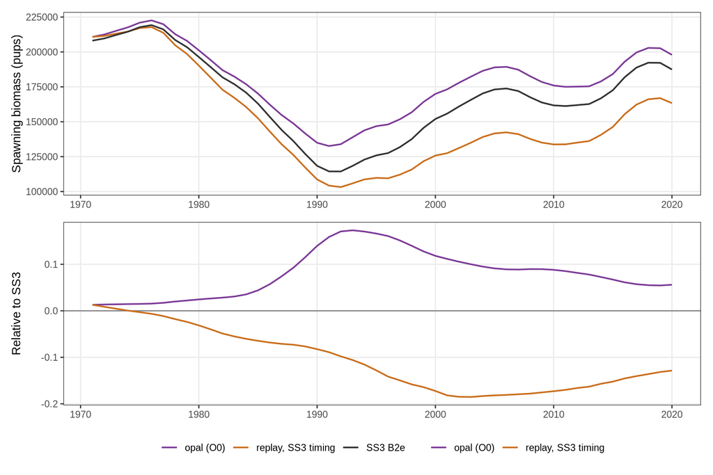

Figure 3: O0: opal at SS3’s values against SS3 B2e (top: spawning biomass; bottom: relative difference). ‘Replay, SS3 timing’ replays the converted inputs with SS3’s Baranov catch equation.

```r
br = copy(opal_c$bridge)
br[, year := 1970 + ts]
bl = rbind(br[, .(year, series = "SS3 B2e", value = ss3)],
           br[, .(year, series = "opal (O0)", value = opal)],
           br[, .(year, series = "replay, SS3 timing", value = replica_ss3)])
rel = rbind(br[, .(year, series = "opal (O0)", value = rel_opal)],
            br[, .(year, series = "replay, SS3 timing", value = rel_replica_ss3)])
o0_col = c("SS3 B2e" = "grey20", "opal (O0)" = "#7D3C98", "replay, SS3 timing" = "#CA6F1E")
p1 = ggplot(bl, aes(year, value, colour = series)) + geom_line(linewidth = 0.7) +
    scale_colour_manual(values = o0_col) +
    labs(x = NULL, y = "Spawning biomass (pups)", colour = NULL)
p2 = ggplot(rel, aes(year, value, colour = series)) + geom_hline(yintercept = 0, colour = "grey50") +
    geom_line(linewidth = 0.7) + scale_colour_manual(values = o0_col) +
    labs(x = NULL, y = "Relative to SS3", colour = NULL)
(p1 / p2) + plot_layout(guides = "collect") & theme(legend.position = "bottom")
```

The first year agrees to 1.3%: the initial equilibrium, initial F and initial deviations are converted directly. Recruitment then tracks SS3 to within a few percent, but spawning biomass drifts up to 17% above SS3 in the high-catch years around 1990-1995. Two timing differences account for this:

- **Catch.** opal removes each year’s catch at the start of the year, before natural mortality, as a harvest rate; SS3 removes it continuously (hybrid F). With F<sub>2020</sub> about 0.34 and M of 0.79 at age 0, the start-of-year removal leaves more fish alive.
- **Catch weight.** SS3 converts catch in weight to numbers with mid-year weights; opal with its single weight-at-age vector (start of year). For the same tonnage opal removes more, smaller fish.

The replay with SS3’s catch equation but opal’s start-of-year weights overshoots the other way (19%); with SS3’s mid-year weights it is within 8% of SS3 (tested in `tests/testthat/test-ss3-to-opal-npo-bsh.r`), which places the remaining gap in SS3’s subseason and initial-equilibrium details rather than in the conversion. In opal itself the two effects partly cancel, which is why opal uses start-of-year weights here: mid-year weights would double the gap. `simulations/timing/` studies the catch-timing difference in general.

# 5 opal fits

Two fits. Growth, h, sigma<sub>R</sub>, the biology and F4’s initial F stay at SS3’s values; opal’s default priors are switched off, as SS3 has no parameter priors. SS3 ties the initial F to an initial-equilibrium catch of 40,000 t (SE 0.05) through a likelihood term opal does not have; left free in opal, the initial F doubled (0.11 to 0.22) and depleted the 1971 stock to 0.37 of B<sub>0</sub>.

- **O1** keeps SS3’s selectivity-at-age and estimates B<sub>0</sub>, the recruitment deviations, the initial age structure (1971 recruitment and the ten early deviations) and the two catchabilities, starting at SS3’s values.
- **O2** uses opal’s own length-based double normals, started at SS3’s curves, and also estimates the selectivity parameters SS3 estimated (peak and widths, within SS3’s bounds on opal’s scale); mirrored fleets share their source’s parameters, as in SS3. It starts from O1’s estimates.

```r
knitr::kable(S[, .(Model = model, `Est. par.` = n_par,
                   Objective = ifelse(is.na(objective), "", fmt(objective, 2)),
                   `Max gradient` = ifelse(is.na(max_gradient), "", sci(max_gradient, 1)),
                   `opal_check()` = ifelse(is.na(check_passes), "", ifelse(check_passes, "pass", "fail")),
                   B0 = fmt(B0, 0), `SSB 2020` = fmt(ssb_2020, 0),
                   `SSB2020/B0` = fmt(depletion_2020, 3),
                   `Index NLL` = ifelse(is.na(lp_cpue), "", fmt(lp_cpue, 2)),
                   `Length NLL` = ifelse(is.na(lp_lf), "", fmt(lp_lf, 1)))],
             format = "pipe", align = "lrrrlrrrrr")
```

Table 7: Fits. The objective values are opal’s and are not comparable with SS3’s likelihood (different constants, and opal’s compositions are predicted differently).

| Model | Est. par. | Objective | Max gradient | opal_check() | B0 | SSB 2020 | SSB2020/B0 | Index NLL | Length NLL |
| --- | --- | --- | --- | --- | --- | --- | --- | --- | --- |
| SS3 B2e | 109 |  |  |  | 349,989 | 187,433 | 0.536 |  |  |
| O0 | 0 | 1,761.34 |  |  | 349,989 | 197,925 | 0.566 | -33.39 | 1,515.2 |
| O1 | 64 | 1,716.99 | 5.4e-04 | fail | 3,584,912,846 | 3,698,453,222 | 1.032 | -26.01 | 1,460.3 |
| O2 | 108 | 1,442.48 | 1.6e-01 | fail | 419,109 | 281,966 | 0.673 | -36.09 | 1,206.7 |
| O1-noLF | 64 | -31.62 | 5.7e-11 | pass | 336,369 | 179,551 | 0.534 | -35.07 | 1,529.1 |
| O1-mid | 64 | 1,554.99 | 4.8e-09 | pass | 319,522 | 175,548 | 0.549 | -31.51 | 1,315.8 |

```r
o1 = S[model == "O1"]
o2 = S[model == "O2"]
conv = function(x) if (isTRUE(x$check_passes)) "converged and passes `opal_check()`" else
    sprintf("did not converge (maximum gradient %s)", sci(x$max_gradient, 1))
```

O1 does not find an interior optimum: B<sub>0</sub> runs to the upper bound of its search range (3,584,912,846, ln B<sub>0</sub> = 22), where the stock is effectively unexploited (terminal depletion 1.032), although O1 uses SS3’s selectivity and starts at SS3’s values (O0, depletion 0.566; SS3 0.536). The likelihood is still falling at the bound, so its estimates are not reported as such. O2 did not converge (maximum gradient 1.6e-01) and is shown for completeness only: freeing opal’s selectivity improves the fit to the compositions by 254 units over O1 while improving the fit to the indices by 10.1, and the optimiser does not settle (several widths move to the flat ends of the double normal, where the gradient vanishes). Its depletion of 0.673 should not be read as an estimate.

## 5.1 What moves opal away from SS3

```r
nolf = S[model == "O1-noLF"]
mid  = S[model == "O1-mid"]
```

Two diagnostic refits of O1 locate the difference (Table 7, Figure 4):

- **Without the length compositions** (O1-noLF, lambda 0), opal’s estimate matches SS3’s: terminal depletion 0.534, B<sub>0</sub> 336,369. opal’s dynamics, the indices and the recruitment penalty agree with SS3’s; the compositions are what push O1 away.
- **With SS3’s mid-year length-at-age** in place of opal’s growth when the compositions are predicted (O1-mid), depletion is 0.549, close to SS3’s. SS3 predicts a fishery’s length composition from its catch over the year; opal predicts it from numbers at the start of the year with start-of-year lengths. Because recruits settle in month 7, SS3’s age-1 class is only half a year past settlement at the start of the year (34.7 cm) and reaches L1 (64.3 cm, age 1 post-settlement) at mid-year; the gap is 13 cm at age 2 and shrinks with age. With SS3’s start-of-year length-at-age instead the fit runs away (B<sub>0</sub> over 10<sup>7</sup>), as it does with opal’s own Schnute growth, which is fitted to those start-of-year lengths (O1). An earlier version of the converter passed the growth reference ages to opal as ages rather than positions, which made opal’s fish one year older (and larger) at every age; with that error O1 had settled at a depletion of 0.25.

O1-mid uses `ss3_patch_opal_external_laa()`, a local edit of opal’s model function that substitutes a supplied length-at-age; it is a diagnostic, not a way to fit opal. What opal would need is length-at-age, and the age composition of the catch, at the time each observation is made (Section 6).

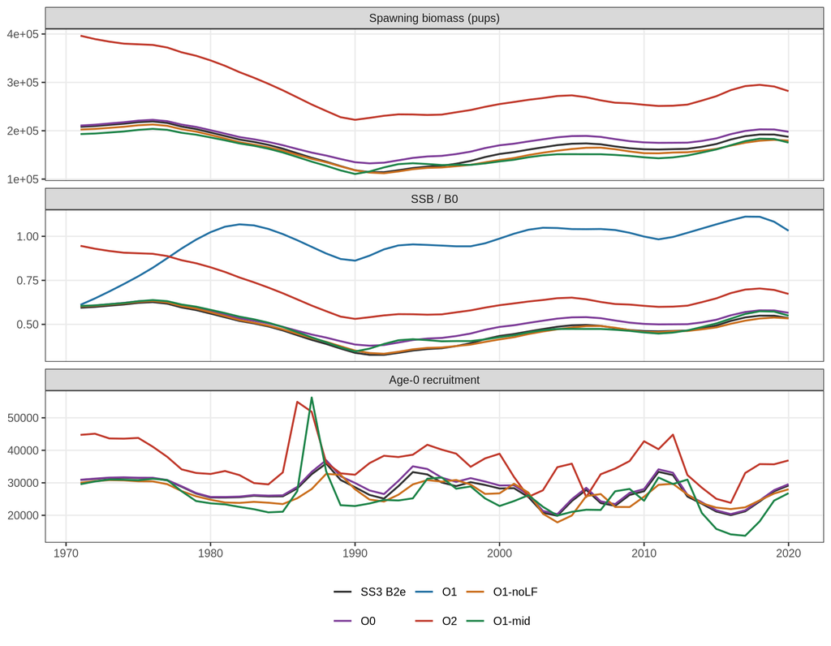

Figure 4: Spawning biomass, depletion and age-0 recruitment: SS3 B2e and the opal models (O1, whose B0 is at its bound, in the depletion panel only).

```r
tr = copy(opal_c$trajectory)
tr[, model := factor(model, levels = names(model_col))]
tl = melt(tr[, .(model, year, `Spawning biomass (pups)` = ssb, `SSB / B0` = depletion,
                 `Age-0 recruitment` = recruits)], id.vars = c("model", "year"))
# O1's scale is at the bound on B0 (@sec-fits): shown for depletion only
tl = tl[!(model == "O1" & variable != "SSB / B0")]
ggplot(tl, aes(year, value, colour = model)) +
    geom_line(linewidth = 0.7) +
    facet_wrap(~variable, ncol = 1, scales = "free_y") +
    scale_colour_manual(values = model_col) +
    labs(x = NULL, y = NULL, colour = NULL)
```

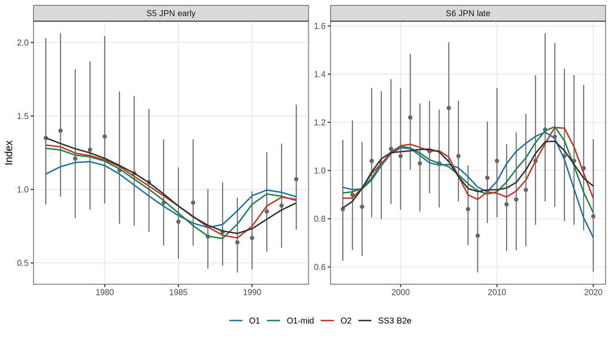

Figure 5: Fits to the two indices (points: observed, with 95% intervals from the input SE).

```r
cp = copy(opal_c$cpue)
cp[, index := c("S5 JPN early", "S6 JPN late")[index]]
obs = unique(cp[model == "SS3 B2e", .(index, year, obs, se)])
ggplot(cp, aes(year)) +
    geom_pointrange(data = obs, aes(y = obs, ymin = obs * exp(-1.96 * se), ymax = obs * exp(1.96 * se)),
                    colour = "grey40", size = 0.2) +
    geom_line(aes(y = pred, colour = model), linewidth = 0.7) +
    facet_wrap(~index, scales = "free") +
    scale_colour_manual(values = model_col) +
    labs(x = NULL, y = "Index", colour = NULL)
```

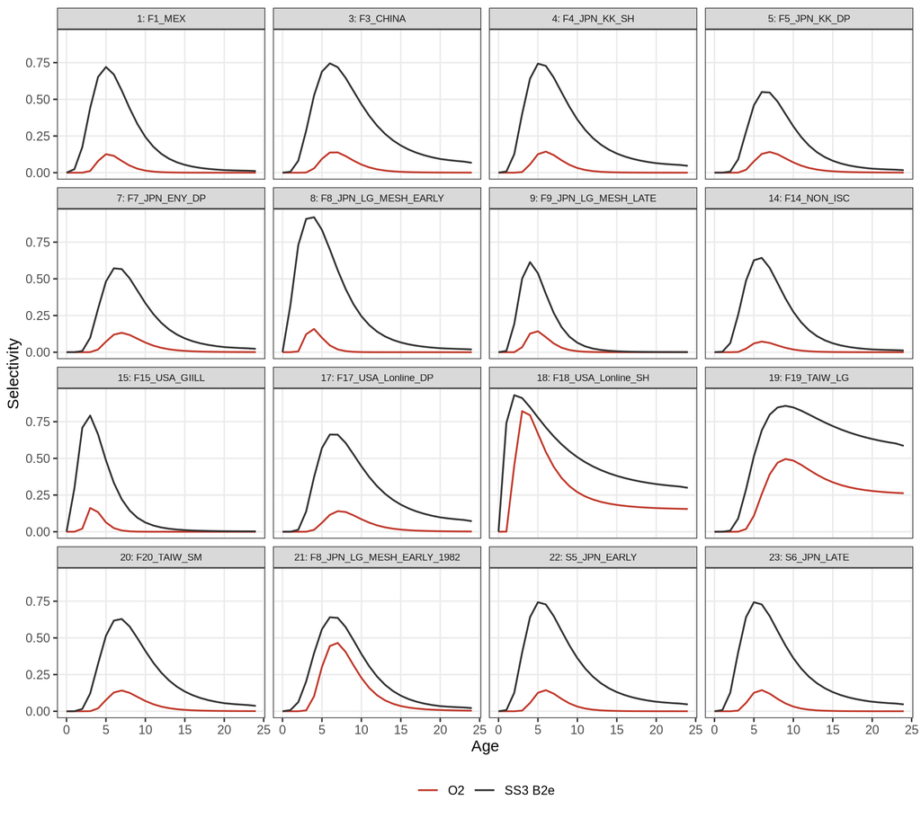

Figure 6: Selectivity-at-age in 2020: SS3 B2e (black) and opal O2 (red; not converged), for the opal fisheries with length data and the two indices.

```r
sel = copy(opal_c$selectivity)
fl = opal_c$fleets
keep = c(1, 3, 4, 5, 7, 8, 9, 14, 15, 17, 18, 19, 20, 21, 22, 23)
sel = sel[fishery %in% keep]
sel[, panel := factor(sprintf("%d: %s", fishery, fl$name[fishery]),
                      levels = sprintf("%d: %s", keep, fl$name[keep]))]
ggplot(sel, aes(age, sel, colour = model)) +
    geom_line(linewidth = 0.6) +
    facet_wrap(~panel, ncol = 4) +
    scale_colour_manual(values = c("SS3 B2e" = "grey20", O2 = "#C0392B")) +
    labs(x = "Age", y = "Selectivity", colour = NULL) +
    theme(strip.text = element_text(size = 7))
```

# 6 Limitations and differences from SS3

## 6.1 Not available in opal

- **Two sexes.** opal tracks one population vector and scales spawning potential by a sex ratio. Modelling S6 needs a sex dimension in the numbers at age, sex-specific growth, M and selectivity (including SS3’s offset parameterisations), sex-specific or joint sex-by-length compositions, and spawning biomass from females only.
- **Cubic-spline selectivity** (S6’s F18). opal has logistic, double normal and double Richards curves, or a fixed external matrix.
- **Time-varying selectivity.** Blocks (F8) and deviations (F19) cannot be estimated. Blocks that replace parameters are reproduced exactly by splitting the fleet (B2b); deviations have no equivalent (B2c).
- **Initial-equilibrium catch.** SS3 fits the catch implied by the initial F (40,000 t for F4 here) as data; opal has no such term, so its initial F is fixed at SS3’s value.
- **Regime offset on the initial equilibrium recruitment**, and SS3’s **F-ballpark** penalty. opal fits catch exactly with harvest rates, so it does not need the latter for convergence, but as Section 3 shows the penalty carried information on scale.
- **Generalised size-frequency data** on irregular bins as a separate data type with its own weighting (one F11 observation here, not carried).

## 6.2 Structural differences handled in the conversion

- **Catch timing.** opal removes each season’s catch at its start; SS3 here removes it continuously (hybrid F). This is the largest difference at SS3’s values (Figure 3). Sub-annual opal seasons with the catch split across them would approximate continuous removal, but opal’s single weight-at-age vector would still apply start-of-year weights in every season.
- **Observation timing.** SS3 observes the indices in month 7 and the fishery compositions over the year (catch-weighted, with mid-year lengths); opal predicts both from numbers and lengths at the start of the season. For this annual model, with recruits settling in month 7 and start-of-year lengths 30 cm below mid-year lengths at age 1, this is the difference that matters most once opal is fitted: with mid-year lengths O1’s terminal depletion is about 0.55, as in SS3; with start-of-year lengths O1’s scale runs away (Section 5). opal would need observation-time length-at-age (growth evaluated at the fraction of the year or season when the fleet fishes) and catch-weighted predicted compositions; sub-annual seasons would approximate both.
- **Growth below the first reference age and settlement timing.** SS3 grows fish linearly from settlement (month 7, at the 5 cm minimum size) to age 1 post-settlement; opal has no settlement time and its Schnute curve, fitted to SS3’s start-of-year lengths, extrapolates von Bertalanffy growth below age 1. On the endgrowth biology route this only affects the PLA used for selectivity.
- **Extra index SD.** SS3 adds it to the input SE; opal combines its own tau in quadrature. The converter adds SS3’s value to the input SE and opal’s tau stays at zero.
- **Catchability.** SS3 solves it analytically (floating q); opal estimates it.
- **Fleet layout.** SS3 3.30 allows fishing fleets after surveys (fleet 32 here); the converter maps SS3 fleets to opal fisheries by fleet type.

## 6.3 What the bridge itself changes

The single-sex step is not neutral: B1’s stock is smaller and more depleted than S6’s. Female growth is applied to males (who are larger), each selectivity curve becomes S6’s male curve, and the compositions lose their sex information. Because S6 estimates female selectivity to be well below male selectivity in nearly every fishery (with no spatial structure, selectivity absorbs the females’ lower availability to the gear; report §8.4), the single-sex model fishes the spawning stock harder than S6 does. A bridge that keeps one sex but uses S6’s female selectivity, or a selectivity averaged over the catch’s sex ratio, would separate this effect from growth. A sex-averaged biology (the planned sensitivity B1b) would show how much of the change comes from growth and M rather than from the selectivity and the compositions.

# Reproducing this document

| Step | Script | Writes |
| --- | --- | --- |
| 1 | `scripts/01-build-ss3-bridge.r` | the SS3 bridge models and `vignettes/data/npo-bsh-ss3-bridge-cache.rds` |
| 2 | `scripts/02-profile-ss3-r0.r` | `vignettes/data/npo-bsh-ss3-r0-profile-cache.rds` |
| 3 | `scripts/03-convert-fit-npo-bsh-opal.r` | `vignettes/data/npo-bsh-opal-cache.rds` and the fitted models |
| 4 | `quarto render vignettes/npo-bsh-ss3-to-opal.qmd` | this document |

```r
cat(sprintf("Caches: bridge %s (SS3 %s); opal %s (opal %s, r4ss %s, R %s).\n",
            bridge$made_at, bridge$ss3_version, opal_c$created,
            opal_c$session$opal, opal_c$session$r4ss, opal_c$session$r))
```

```
Caches: bridge 2026-10-28 05:33:40 UTC (SS3 3.30.22.1); opal 2026-10-30 01:30:04 UTC (opal 0.1.2, r4ss 1.56.0, R 4.5.3).
```

# References

ISC Shark Working Group. 2022. *Stock Assessment and Future Projections of Blue Sharks in the North Pacific Ocean Through 2020*. Report of the 22nd Meeting of the ISC, Annex 12. International Scientific Committee for Tuna; Tuna-Like Species in the North Pacific Ocean. https://isc.fra.go.jp/pdf/ISC22/ISC22_ANNEX12_Stock_Assessment_for_Blue_Shark.pdf.